# Stepping Stones

### Children in Foster Care

Children in foster care are among our most vulnerable children. The rate of family separation is both an indicator of child welfare and of the unmet need or underinvestment in policies and resources to support families in the community. Neglect, often a proxy for the effects of poverty, is [one of the most common reasons for a child’s removal from the home nationally](https://www.childrensdefense.org/state-of-americas-children/soac-2021-child-welfare/), including “failure to provide adequate nutrition, supervision, health care, clothing, or housing.”

- **Data considerations:** While this data counts all children in foster care at a point in time, a child’s presence in foster care occurs only after multiple decisions made by people in a position of authority. These data, then, reflect a series of actions, evaluations, and decisions, many of which are subject to interpretation. Research has long shown that minoritized populations, especially Black children, are overrepresented in foster care, and legal and social researchers have [repeatedly](https://www.hachettebookgroup.com/titles/dorothy-roberts/shattered-bonds/9780465070596/) [documented](https://cssp.org/wp-content/uploads/2018/11/CSSP-Entangled-Roots.pdf) the ways child welfare systems are [entangled](https://www.childrensrights.org/wp-content/uploads/2023/04/CR-Racism-at-the-Front-End-of-Child-Welfare-2023-Fact-Sheet.pdf) with [race](https://www.hachettebookgroup.com/titles/dorothy-roberts/torn-apart/9781541675445/).
- **How is this measured?:** This metric reports the number of children in foster care on October 1 of each year divided by the number of children aged 0-17 in the area and multiplied by 1,000.

#### Notable Trends

- The rate of children in foster care has been consistently higher in Charlottesville than in Albemarle. The rate in Albemarle has remained relatively steady, at around 5 children per 1,000, during this period. The rate in Charlottesville has fallen substantially over time, from rates above 20 children per 1,000 from 2006 to 2011 to 10 or fewer children per 1,000 in 2021 and 2022.

##### Rate of Children in Foster Care, Measured Yearly on October 1st, for Albemarle County, City of Charlottesville, and Virginia

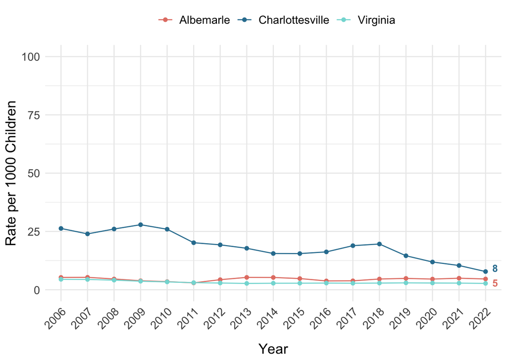

**Source:** [Virginia Department of Social Services, Foster Care Reports](https://www.dss.virginia.gov/geninfo/reports/children/fc.cgi), “Children Demographics.” 2006-2022.

## School and Community Disciplinary Actions

### School Reports of Discipline (Alcohol and Drug Violations, Physical Violence, and Weapon Possession)

These data capture the recorded student offenses relating to alcohol and drug violations, incidents of physical violence, and possession of weapons in schools. These measures offer insight into student safety and health as well as risk behaviors and involvement with law enforcement. For each metric, it is the rate of incidents per 1,000 students; this is not equivalent to the number of students reported for an offense as an individual student could be reported multiple times.

- **Data considerations:** These data are derived from school administrative data from the Virginia Department of Education (VDOE). They capture only incidents observed and reported by school authorities. That is, these records do not occur by default but require someone to observe or evaluate an action or behavior and make a judgment about whether the behavior should be referred to the administrative systems. Consequently, these data provide a picture of characteristics that were captured with discretion – some events are surely not observed, and among observed events some are not reported. These data, then, do not necessarily provide a complete representation of relevant events. Further, the requirements for reporting these disciplinary data have changed over time, as have the categories of behaviors. Thus, the records from earlier reports (2006-07 to 2016-17) may not be completely comparable to the records from recent reports (2017-18 to 2020-21).
- **How are these measured?:** For each measure, the number of relevant incidents from the Discipline, Crime, and Violence (DCV) Annual Report are summed and the total is divided by the number of students in the school division (and multiplied by 1,000). DCV reports for the 2013-14 through 2016-17 school years do not provide school division summaries.
  - Alcohol and drug violation reporting categories for 2017-18 through 2020-21 are “Alcohol violations” and “Drug violations;” for 2006-2007 through 2016-17 categories are “Alcohol”, “Drug violations”, and “Possession/use/sale/distribution of OTC.”
  - Physical violence reporting categories for 2017-18 through 2020-21 are “Assault/Battery”, “Fighting/Conflict”, “Kidnapping”, “Robbery/Person/Force or Threat of Force”, “Sexual Offenses”, “Threats/Verbal/Physical;” for 2006-2007 through 2016-17 categories are “Aggravated sexual battery”, “Battery against staff w/o weapon”, “Battery against student w/o weapon”, “Fighting w/o injury”, “Homicide”, “Kidnapping”, “Malicious wounding”, “Robbery using force”, “Sexual assault”, “Sexual battery”, “Sexual offenses”, and “Threat.”
  - Weapons possession reporting category for 2017-18 through 2020-21 is “Weapons;” for 2006-2007 through 2016-17 categories are “Handgun, rifle/shotgun and other firearms”, “Other weapons and explosive devices”, “Possession of taser/stun gun”, “Possession of razor blades, box cutters”, “Possession of a toy or look alike gun”, and “Possession of fireworks.”

#### Notable Trends

- Drug and alcohol violations are consistently at or below 5 per 1,000 students in both Charlottesville City Schools (CCS) (except for 2006-07), Albemarle County Public Schools (ACPS), and Virginia as a whole (except for 2012-13). In the 2020-21 school year, the rate dropped to 0.2 in ACPS and 0 in CCS.
- Physical violence in CCS dropped considerably from 2006-07, at 60 incidents per 1,000 students, to 2012-13, at 19 incidents per 1,000 students. In ACPS, the rate of physical violence ranged between 6 to 12 incidents per 1,000 students during this same period. The trend from recent years may not be capturing precisely the same kinds of events given the change in reporting requirements and formats; The rate of recorded incidents of physical violence in the 2020 school year was 0.5 in both divisions.
- Weapons possession hovered around 3 to 4 incidents per 1,000 students in CCS and 1 to 2 incidents per 1,000 students in ACPS in the 2006 to 2012 period. The rate has dropped even further in recent years to near zero.

##### Rate of Incidents of Alcohol and Drug Violations for Albemarle County Public Schools, Charlottesville City Schools, and Virginia Public Schools

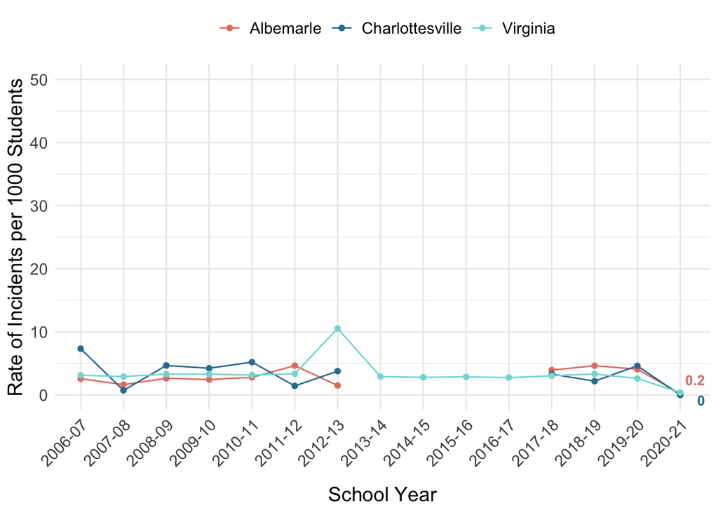

##### Rate of Incidents of Physical Violence for Albemarle County Public Schools, Charlottesville City Schools, and Virginia Public Schools

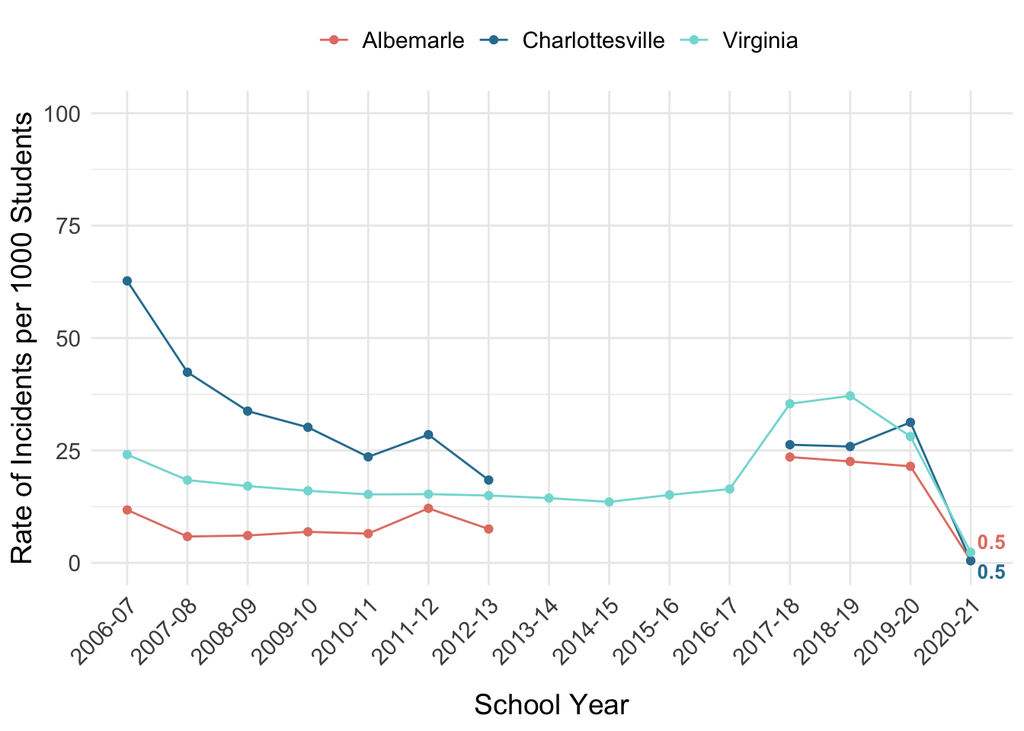

##### Rate of Incidents of Weapons Possession for Albemarle County Public Schools, Charlottesville City Schools, and Virginia Public Schools

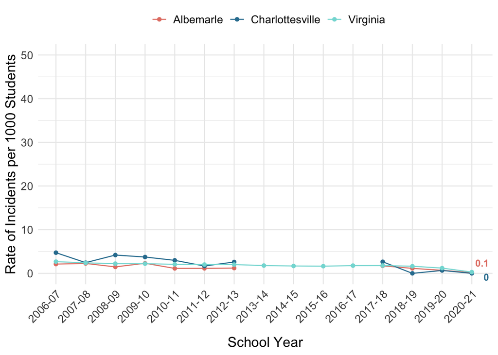

**Source:** [Virginia Department of Education, School Climate Reports](https://www.doe.virginia.gov/data-policy-funding/data-reports/data-collection/special-education), “Discipline, Crime, and Violence Annual Report.” 2006-2020.

### Out-of-School Suspensions

School suspensions are an exclusionary disciplinary tool that temporarily removes students from their schools for a violation of school policies or rules. Being suspended from school is associated with multiple poor outcomes including lower academic achievement, lower quality relationships with teachers, and involvement in the criminal justice system. A 2016 report by the [Legal Aid Justice Center](https://www.justice4all.org/wp-content/uploads/2016/04/Suspended-Progress-2017.pdf) noted the majority of suspensions issued statewide in Virginia were for “non-violent, relatively minor misbehavior.”

- **Data considerations:** These data are derived from school administrative data from the Virginia Department of Education (VDOE). They capture only individuals and incidents observed and reported by school authorities. That is, these records do not occur by default but require someone to observe or evaluate an action or behavior and make a judgment about whether the behavior should result in a suspension. Consequently, these data provide a picture of characteristics that were captured with discretion. In addition, VDOE suppresses counts for suspensions if they are less than 10. Data for long-term suspensions was suppressed in several years for both Albemarle County Public Schools (ACPS) and Charlottesville City Schools (CCS), so these counts slightly underestimate the number of suspensions. This metric presents the number of suspensions per 1,000 students; this is not equivalent to the number of students suspended as an individual student could be suspended multiple times.
- **How is this measured?:** Out-of-school suspensions include short-term suspensions, long-term suspensions, and modified expulsions to suspensions. The rate of students suspended is the count of students given an out-of-school suspension divided by the total students enrolled in a school division, multiplied by 1,000.

#### Notable Trends

- The suspension rate in CCS was above 200 per 1,000 students before 2009-10 and ACPS was well above 100 in the same period. The suspension rate has dropped dramatically in CCS since 2009.
- In recent years, CCS and ACPS have had a similar suspension rate around 35-40 students per 1,000 enrolled. The rate dropped to near zero during the 2020 school year, when schools implemented hybrid learning schedules in response to the COVID-19 pandemic.

##### Rate of Out-of-School Suspensions (Short-term Suspension, Long-term Suspension, or Modified Expulsion to Suspension) for Albemarle County Public Schools, Charlottesville City Schools, and Virginia Public Schools

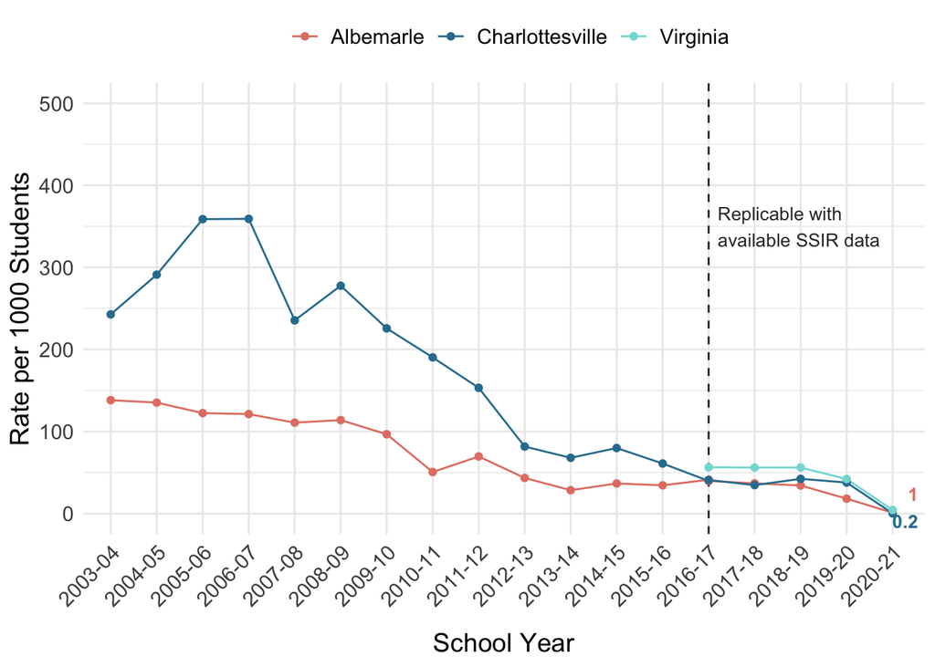

**Source:** Virginia Department of Education, “[Safe Schools Information Resource (SSIR)](https://p1pe.doe.virginia.gov/pti/selection.do).” 2017-2021. SSIR maintains only the most recent 5 years of reports at a given time; previously collected SSIR data was appended to see wider trends, but was not further verified for this report.

### Children in Need of Services or Supervision

This measure tracks the number of judgments of a child in need of supervision, a young person who is truant or has run away from home, and the number of judgments of a child in need of services, a young person whose behavior, conduct, or condition presents or results in a serious threat to himself or another person. A CHINS petition can be filed by parents, police, and school authorities and is adjudicated in Juvenile Court. According to Virginia Code [§ 16.1-278.4](https://law.lis.virginia.gov/vacode/title16.1/chapter11/section16.1-278.4/) and [§ 16.1-278.5](https://law.lis.virginia.gov/vacode/title16.1/chapter11/section16.1-278.5/), a child who has been found in need of services or supervision may be subject to probation, transfer of custody, or rehabilitative treatment.

- **How is this measured?:** This metric counts the number of judgments of children in need of supervision and children in need of services issued in a court jurisdiction divided by the number of residents aged 10-17 in the locality (multiplied by 1,000).

#### Notable Trends

- The rate has been consistently higher in Charlottesville than in Albemarle, peaking at 29 per 1,000 youth in 2016, and falling to between 4 and 6 per 1,000 youth in 2019 and in the years after.
- The rate in Albemarle peaked at 7 in 2014 and has fallen to between 1 and 3 per 1,000 youth in 2022.

##### Rate of Youth (Age 10-17) in Need of Services or Supervision for Albemarle County, City of Charlottesville, and Virginia

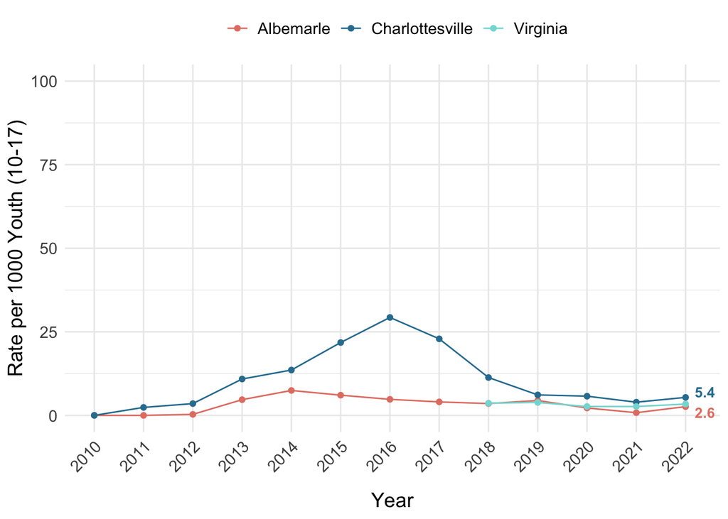

**Source:** [Virginia Judicial System, Caseload Statistical Information](https://www.vacourts.gov/courtadmin/aoc/djs/programs/cpss/csi/home.html), “Caseload Statistics of the Juvenile and Domestic Relations Courts.” 2010-2022.

### Juvenile Delinquency Judgments

This measure tracks the number of judgments of delinquency in the Juvenile and Domestic Relations court. A delinquent judgment may be passed when someone under age 18 commits an act which would be a crime if committed by an adult (including felonies and misdemeanors) and a ruling of delinquency entails escalated involvement with the justice system. According to [Virginia Code § 16.1-278.8](https://law.lis.virginia.gov/vacode/title16.1/chapter11/section16.1-278.8/), juveniles found to be delinquent may be subject to multiple types of sanctions or services: commitment to juvenile justice, probation, substance abuse treatment, fines and restitution, loss of driver’s license, public service project, and others.

- **Data considerations:** These data do not include “status offenses”, behaviors that are not crimes but are prohibited because of a youth’s status as a minor.
- **How is this measured?:** This metric counts the number of juvenile delinquency judgments issued in a court jurisdiction divided by the number of residents aged 10-17 in the locality, multiplied by 1,000.

#### Notable Trends

- The rate of juvenile delinquency judgments has decreased steadily in both Charlottesville and Albemarle. In 2010, the rate in Charlottesville was 131 per 1,000 youth, but fell to 42 in 2022. In 2010, the rate in Albemarle was 51 per 1,000 youth, but fell to 12 in 2022.

##### Rate of Juvenile Delinquency Judgments for Youth, Age 10-17, for Albemarle County, City of Charlottesville, and Virginia

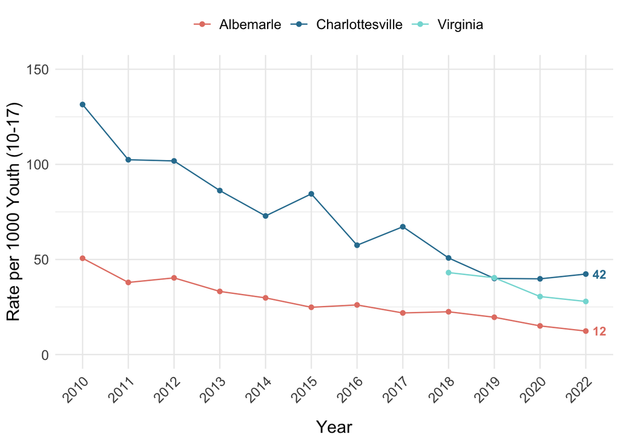

**Source:** [Virginia Judicial System, Caseload Statistical Information](https://www.vacourts.gov/courtadmin/aoc/djs/programs/cpss/csi/home.html), “Caseload Statistics of the Juvenile and Domestic Relations Courts.” 2010-2022.

### Underage Alcohol Arrests

This measure tracks the rate of arrests for alcohol use in youth under 18 years old. Underage drinking, while common, is [associated with multiple risks](https://www.cdc.gov/alcohol/fact-sheets/underage-drinking.htm) for young people, including injury, educational struggles, and physical or sexual violence. This measure does not reflect the prevalence of underage drinking, but the intersection of drinking and policing choices and observation. The majority of underage alcohol use does not result in arrest.

- **Data considerations:** Arrest data capture only instances observed by or reported to police and instances which policing authorities evaluate as being subject to arrest. Multiple selection mechanisms impact the generation of an arrest, including policies and resources as well as the age, race, gender, and class of youth. Additionally, while the legal drinking age in Virginia is 21, these data do not include individuals aged 18-21 as underage arrests.
- **How is this measured?:** The arrest rate is the sum of arrests among juveniles for driving under the influence, liquor law violations, or drunkenness, divided by the number of residents aged 10-19 (multiplied by 1,000).

#### Notable Trends

- The rates of juvenile alcohol arrests in Charlottesville and Albemarle are relatively consistent with statewide trends. There is a downward trend in the rate of arrests since 1999, with a drop to 0.4 per 1,000 youth in Albemarle and 0.2 per 1,000 youth in Charlottesville in 2021.

##### Rate of Underage Alcohol Arrests for Youth Under 18 for Albemarle County, City of Charlottesville, and Virginia

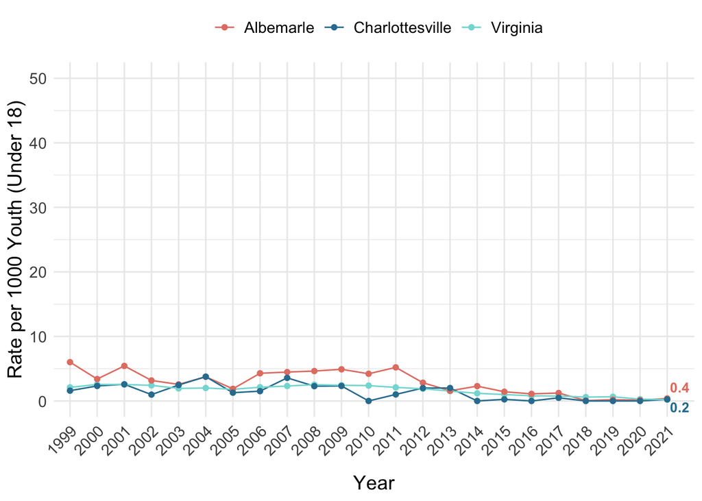

**Source:** [Virginia State Police, Data Analysis and Reporting Team](https://vsp.virginia.gov/sections-units-bureaus/bass/criminal-justice-information-services/uniform-crime-reporting/), “Crime in Virginia.” 1999-2021.

### Arrests for Violent Crimes

This measure tracks the rate of arrests of youth under 18 for crimes against persons. Arrest data capture only instances observed by or reported to police and instances which policing authorities evaluate as being subject to arrest.

- **Data considerations:** Multiple selection mechanisms impact the generation of an arrest, including policies and resources as well as the age, race, gender, and class of youth. Additionally, not all crimes generate an arrest and not everyone who is arrested has committed the crime for which they were arrested. Thus, it is important not to equate this metric with the occurrence of crime among youth.
- **How is this measured?:** The arrest rate is the sum of arrests among juveniles for crimes against persons including murder, negligent manslaughter, kidnapping, sex offenses, aggravated assault, simple assault, and intimidation among juveniles, divided by the number of residents aged 10-19 (multiplied by 1,000).

#### Notable Trends

- Arrest rates in both Albemarle and Charlottesville have seen a mostly downward trend since 2001. In Charlottesville the arrest rate peaked at 15 per 1,000 youth in 2001 and has gone down to 1 per 1,000 youth in 2021.
- Since 2004, the rate of arrests in both the county and city have mostly remained below statewide trends.

##### Rate of Arrests for Crimes against Persons for Youth Under 18 for Albemarle County, City of Charlottesville, and Virginia

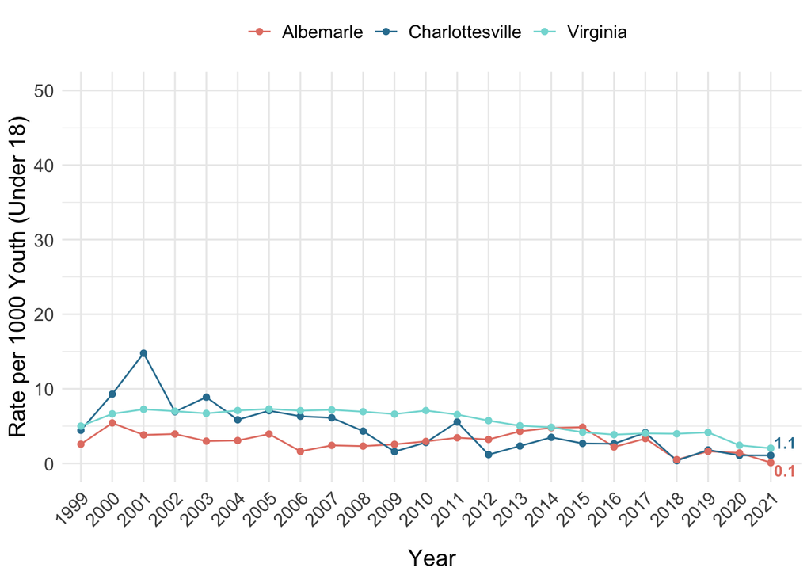

**Source:** [Virginia State Police, Data Analysis and Reporting Team](https://vsp.virginia.gov/sections-units-bureaus/bass/criminal-justice-information-services/uniform-crime-reporting/), “Crime in Virginia.” 1999-2021.

## Contributors

This report is a collaboration of many contributors, including:

- The City of Charlottesville’s Department of Human Services: Misty Graves (Director), Daniel Fairley (Youth Opportunity Coordinator)
- The UVA Equity Center, Democratization of Data Initiative: Michele Claibourn (Director of Equitable Analysis), Beth Mitchell (Data Scientist for Equitable Analysis), Nina Schoonover (Data Scientist for Educational Equity), and Lee LeBoeuf (Equity Data Fellow)
- Batten School of Leadership and Public Policy, Public Interest Data: Ethics & Practice Class: Michele Claibourn (Faculty), Vani Agarwal, Amruta Binoy, Charlie Bruce, Katherine Driebe, Connor Eads, Jayla Hart, Fara Islam, Somin Lee, Michael Lutton, Lekha Mereddy, Maria Morrissey, Owayne Owens, Lily Slonim, Ramya Tella, Mary Katherine West, and Melinda Wong

### About the Department of Human Services (DHS)

The [Department of Human Services (DHS)](https://charlottesville.org/224/Human-Services) was created in 2010 to serve as a human services policy advisor to the City Manager in order to implement the social policy initiatives of the Charlottesville City Council. The vision of the DHS is to serve as the community’s premier provider in meeting the therapeutic needs of youth and families, supporting the community’s efforts to improve equity, and address poverty and its impacts.

The DHS manages the Youth Council, Youth Opportunity Project initiative, Juvenile Justice Advisory Committee, and other related community grants and initiatives. They provide services and programs that improve and support the resilience, health, and well-being of youth, families, and community organizations.

### About the Equity Center and Democratization of Data Initiative

Established in 2019, the mission of the [UVA Equity Center](https://virginiaequitycenter.org/) is to tangibly redress racial and economic inequity in university communities by advancing a transformative approach to the fundamental research mission. We envision universities that serve local communities by bringing rich research resources to bear on the work of redressing poverty and racial inequality and equip students to lead in building a just society.

The [Democratization of Data Initiative](https://virginiaequitycenter.org/democratization-data) centers community-driven partnership to provide advocates as well as civic and private-sector leaders with data and metrics, contextualized analysis, interactive maps and data visualizations, and narrative storytelling as a resource in pursuit of equity throughout the region.

### About Public Interest Data: Ethics and Practice, UVA Batten School of Leadership and Public Policy

[Public Interest Data: Ethics & Practice](https://pidep23.mclaibourn.org/static/syllabus/) (LPPS 5730) is intended to provide students experience with data science within a framework of data ethics in service of equity-oriented public policy. The class goals include:

- Make progress on projects that advance social justice and policy understanding in collaboration with community partners.
- Practice working with data to answer pressing questions, including finding, cleaning, and understanding data; exploring, analyzing, modeling data; visualizing, contextualizing, and communicating data; with care and humility and respect for the affected partners and communities throughout.
- Develop experience in data workflows that support ethical data science, including processes for working collaboratively, openly, inclusively, and reproducibly.

### Project Repository

The work supporting this Stepping Stones Report, including our data collection documentation and the corresponding data, is publicly available in the [Virginia Equity Center GitHub Stepping Stones Repository](https://github.com/virginiaequitycenter/stepping-stones/).

### Citation

Charlottesville Department of Human Services and the UVA Equity Center. *Stepping Stones: A Report on Community Well-Being of Children and Families in the Charlottesville/Albemarle Area*. Published June 2023.

This work is licensed under a [Creative Commons Attribution 4.0 International License](https://creativecommons.org/licenses/by/4.0/).